# Module 3: Data Visualization

Ellen Bledsoe

2022-10-18

# A Visualization Primer

## Why Does Data Visualization Matter?

### On your own

Take 3 minutes to write down your top 5 reasons why data visualization is important or useful to you

### Small Groups

As a group, take 5 minutes to compare your notes and come to a group consensus on your top 5 reasons. Be sure to choose someone to report out!

## Types of Visualization

### Visual cues for communicating data

[Here](http://paldhous.github.io/ucb/2016/dataviz/week2.html) is a decent overview of some of the core concepts of data visualization.

This website is pretty great and goes into a lot of detail about good practices in data visualization. If this is something that really piques your interest, I encourage you to check it out!

In this course, our main take-away from this website is the use of visual cues to communicate data and which ones are better than others.

[figure not shown]

### Small group activity

In groups, discuss as many all types of visualization that come to mind. It’s ok if you don’t know what they are called! Make a quick list or draw them out if you prefer.

[Reference](https://extremepresentation.typepad.com/files/choosing-a-good-chart-09.pdf)

### Data matching activity

Still in your groups, open the PDF called “data_viz_matching_exercise”

Spend a few minutes seeing if you can match the data descriptions to the types of data visualizations. Note: these plots do not represent the data, just a type of data visualization.

This is a challenging exercise, so don’t panic if you feel a little lost! Here are some things to help you think through which visualizations might be appropriate:

- how many variables are in the data description?
- how many variables are represented in the data visualization? Look at the axes, sizes, colors, etc.
- how is *one* data point represented on the plot?
- how is variation in the data represented on the plot, if at all?

#### Matches

1. B
   - circle plots or river plots
   - good for showing movement from one thing to another or relationships between two categorical variables
2. D
   - 4! variables can be shown here—circles could be size of family
   - scatter plots are good at showing relationships between multiple *continuous* variables
3. C
   - Multiple samples for each treatment means we will want to show variation
   - Variation in the multiple samples is show through violin plot; show the mean *and* the distribution of the data
   - One categorical variable and one continuous variable
   - Second categorical variable could be shown through color of violin plot
4. E
   - Heatmaps are good at showing spatial distributions of data
   - x and y axes shows space; the color indicates continuous values
5. A
   - Bar plots are good for showing change through time
   - Categorical on x, continuous on y
   - mutliple stacks, 2 bars per year?

## Figure Critique

First, read through [this blog post](https://humansofdata.atlan.com/2019/02/dos-donts-data-visualization/) on the “Dos and Don’ts of Data Visualization”

Now that you have some insights, let’s critique these figures below. Yes, these are actual figures in the wild…

- what aspects don’t work
- what aspects do work
- how how you present the data?

Figures:

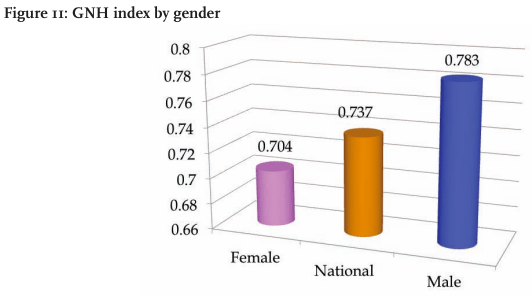

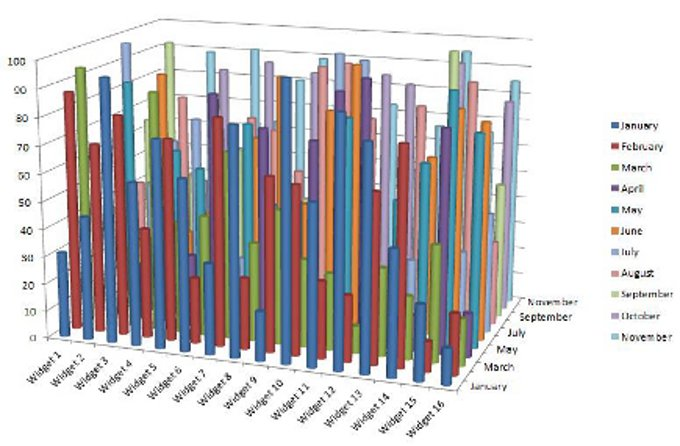

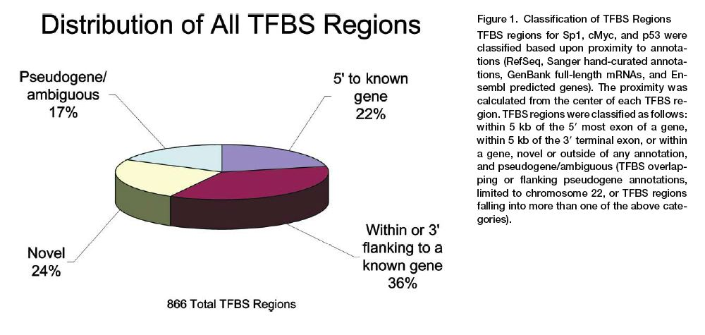

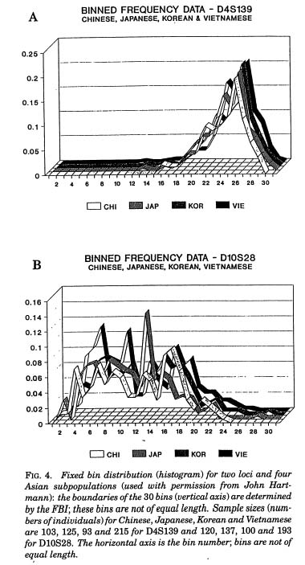

## Plotting in `ggplot2`

Let’s practice making different kinds of plots with various `geom` functions to see how they work. We can use the collar data again.

```r
library(tidyverse)
collars <- read_csv("../data/collar_data.csv")
```

### Scatter plot

As a reminder, we use the `geom_point()` function to make a scatter plot of the relationship between *two continuous variables*.

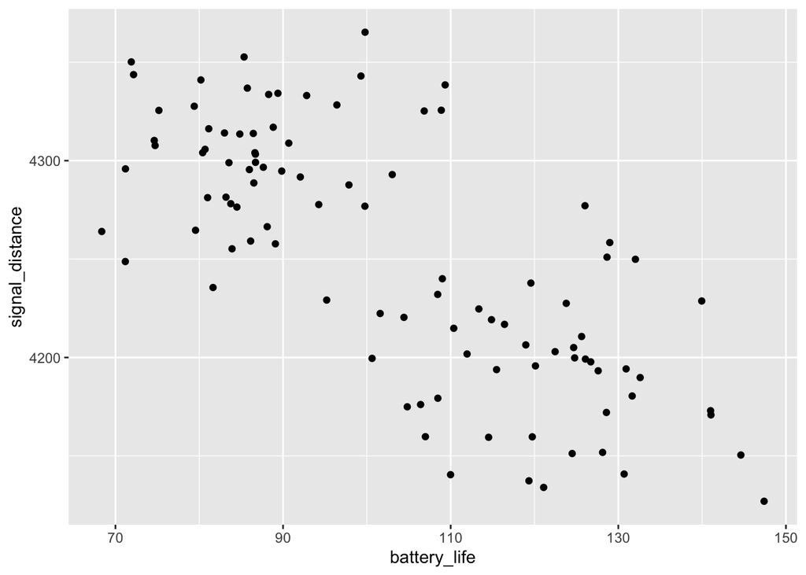

```r
ggplot(collars, aes(battery_life, signal_distance)) +
  geom_point()
```

### Histograms

As we learned last modules, histograms are plots which let us look at *one continuous variable* and get a feel for the distribution of that data. To make histograms in `ggplot2`, we use the `geom_histogram()` function. Let’s look at signal distance.

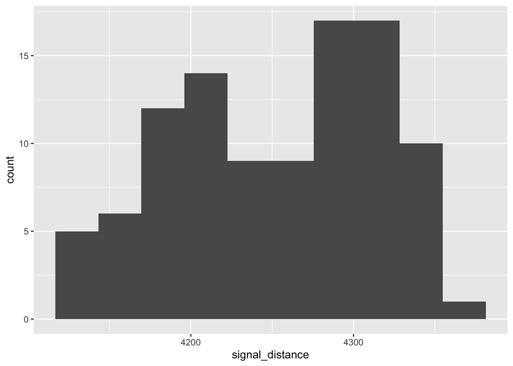

```r
ggplot(collars, aes(signal_distance)) +
  geom_histogram(bins = 10)
```

```r
# we can change the number of bins (essentially, the number of columns) by modifying the bins argument in the geom_histogram function
```

### Density plots

Density plots are similar to histograms in that they show the distribution of a *continuous variable* but they are smoothed and continuous version estimated from the data. For this class, you can think of them as being basically the same thing (and use them interchangeably).

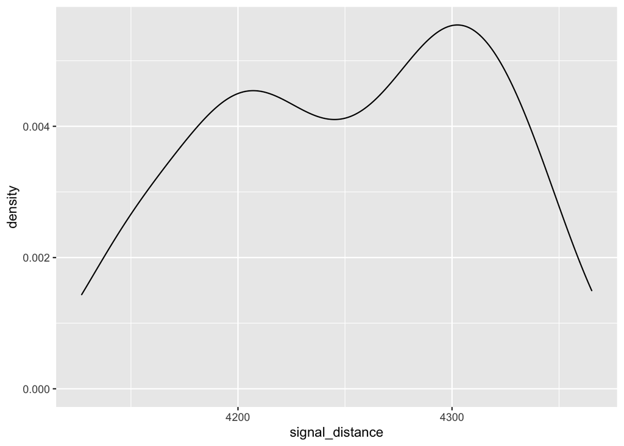

```r
ggplot(collars, aes(signal_distance)) +
  geom_density()
```

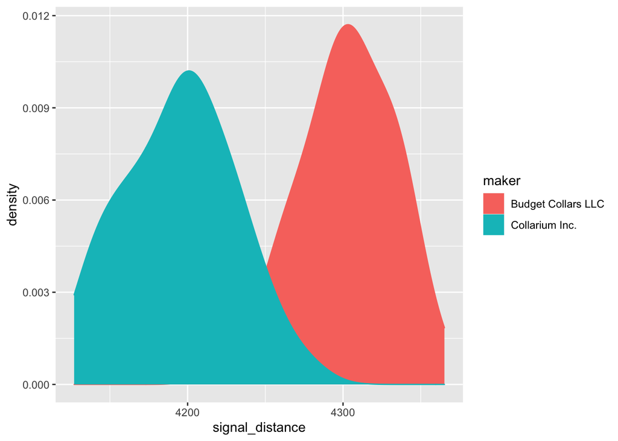

```r
ggplot(collars, aes(signal_distance)) +
  geom_density(aes(color = maker, fill = maker))
```

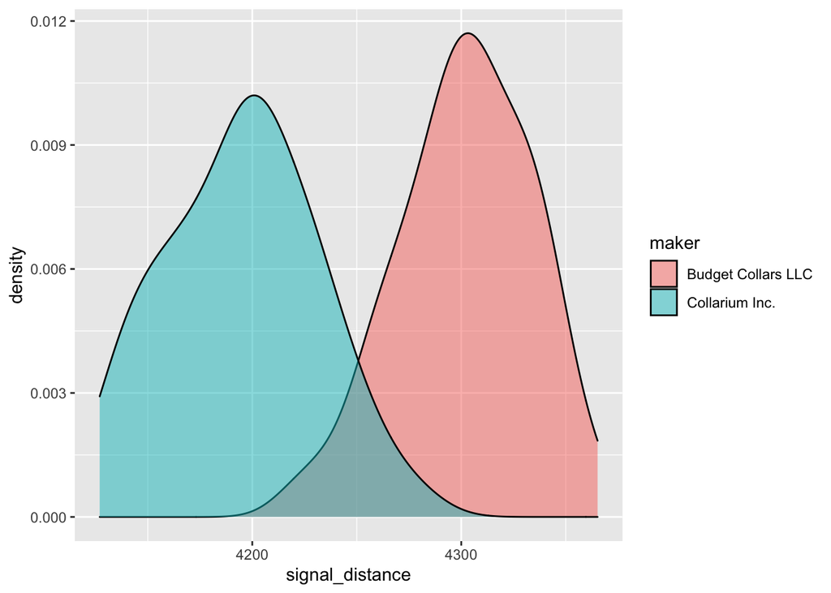

```r
ggplot(collars, aes(signal_distance)) +
  geom_density(aes(fill = maker), alpha = .5)
```

### The powerful and pesky `aes()` function

A quick note about the `aes()` function. It’s one of the more confusing bits of `ggplot2`.

When do I put the `color` (or `size` or `linetype` or `fill` or whatever) inside the `aes()` function versus in the `geom` function but outside of `aes()`? When we made our density plots, why did the `color` argument go inside of `aes()` but `alpha` went outside?

Essentially, it boils down to this:

- if you want something (color, size, etc.) on your plot to change based on a **variable** from a data frame, you will want to put the argument *within* the `aes()` function.
- if you want something (color, size, etc.) on the plot to be **constant**, you will specify it *outside* of the function.

For some additional examples and explanation, check out [this Stack Overflow page](https://stackoverflow.com/questions/41863049/when-does-the-argument-go-inside-or-outside-aes).

### Bar plot

Let’s make a bar plot! They are typically used to represent the counts of *one categorical* variable or the relationship between *one categorical and one continuous variable*. We use the `geom_col` function.

For our example, we can make a bar plot of the number of collars which failed and which did not.

```r
fails <- collars %>%
  group_by(maker, fail) %>%
  count()
fails
```

```
## # A tibble: 4 × 3
## # Groups:   maker, fail [4]
##   maker               fail     n
##   <chr>              <dbl> <int>
## 1 Budget Collars LLC     0    37
## 2 Budget Collars LLC     1    16
## 3 Collarium Inc.         0    43
## 4 Collarium Inc.         1     4
```

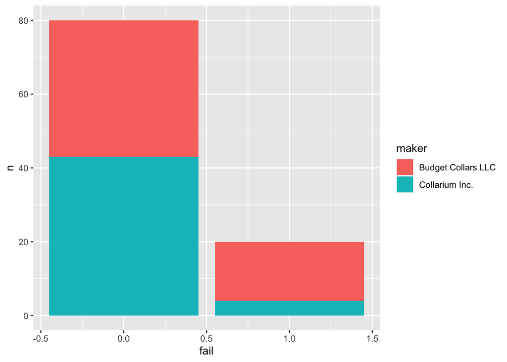

```r
ggplot(fails, aes(fail, n)) +
  geom_col(aes(fill = maker))
```

What we just made is something called a “stacked” bar plot, meaning the values for the two collar makers are stacked one on top of the other. If we wanted them side-by-side, we add the argument `position = "dodge"`.

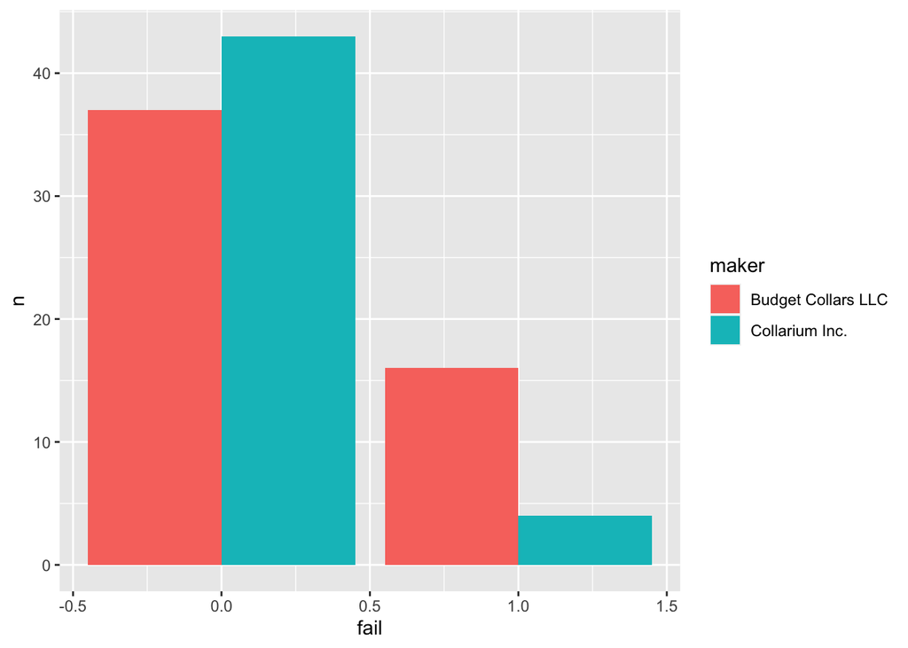

```r
ggplot(fails, aes(fail, n, fill = maker)) +
  geom_col(position = "dodge")
```

## Practice

Hopefully you’re excited to keep using `ggplot2` to make clean, interpretable data visualizations! With the remaining time in class, spend some time trying to recreate the plots you made in Module 2 Assignment 1. Try to recreate both histogram and the scatter plot.

```r
# load the tidyverse package and the penguins package
```